# Machine Learning Programming

## Exercise Session Part 2

### 26th of September 2018

# What is Machine Learning?

> A computer program is said to learn from experience E with respect to some class of tasks T and performance measure P, if its performance at tasks in T, as measured by P, improves with experience E.
> - Mitchell, Tom. M. 1997. Machine Learning. New York: McGraw-Hill

# What is Machine Learning?

> Things learn when they change their behavior in a way that makes them perform better in the future.
> - Witten, Ian H., and Eibe Frank. 2000. Data Mining: Practical Machine Learning Tools and Techniques with Java Implementations. San Diego, CA: Morgan Kaufmann.

# What is Machine Learning about?

- **DATA** (sometimes a lot of them):
  - Gathering them
  - Analyzing them
- Algorithms:
  - Choose the algorithms
  - Program them
- Metric
  - Choose the appropriate one
  - Use it to evaluate the performance

# Different types of learning in this lecture

- **Supervised Learning**: Learns a mapping from some input features to a **known** output
  - Prediction of a feature from the others, e.g. class of the flowers (**classification**)
  - Learn a function that explains your data (**regression**)
- **Unsupervised Learning**: Learns to represent a set of input without any feedback
  - Find a subset of features that represent most of your data (**PCA**)
  - Find group of samples based on their features (**clustering**)

# Previously on Machine Learning Programming

Last week you have seen how to load a dataset and create plotting functions to visualize it.

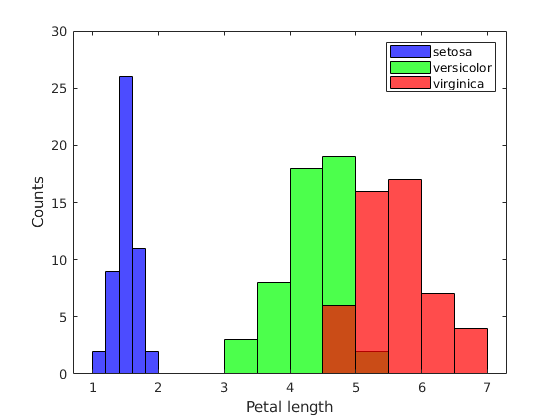

```matlab
plot2DSamples(meas, species, featuresLabel, 3);
```

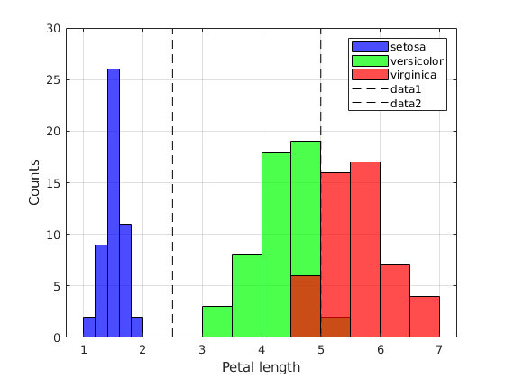

```matlab
plot2DSamples(meas, species, featuresLabel, 3);
line([2.5,2.5], [0,30], 'Color', 'black', 'LineStyle','--')
line([5,5], [0,30], 'Color', 'black', 'LineStyle','--')
grid on
```

# Training a ML model

[figure not shown]

# Training and testing sets with new test data

[figure not shown]

# Training and testing sets with splitted dataset

[figure not shown]

# Training and testing sets with splitted dataset

[figure not shown]

# K-Fold Cross Validation Initialization

[figure not shown]

# K-Fold Cross Validation Step 1

[figure not shown]

# K-Fold Cross Validation Step 2

[figure not shown]

# K-Fold Cross Validation Step 3

[figure not shown]

# K-Fold Cross Validation

[figure not shown]

# K-Fold Cross Validation

[figure not shown]

# Goal of this session

Two points will be covered in this session:

- Split your dataset between **train** and **test** sets
  - from a splitting ratio
  - using K-fold
- Create and train predefined ML models
  - create functions to evaluate the performances
  - train and select the best model

# Exercise 2: Split a dataset for training

Split the Iris dataset into train and test set given a certain proportion for validation.

```matlab
validSize = 0.2;
[xTrain, yTrain, xTest, yTest] = trainTestSplit(meas, species, validSize, seed);
```

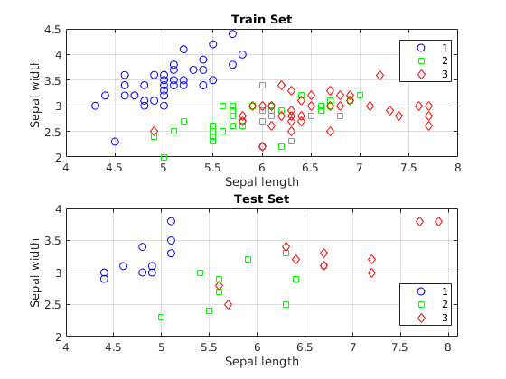

```matlab
% split the dataset in train and test set (use trainTestSplit function)
[xTrain, yTrain, xTest, yTest] = trainTestSplit(meas, species, 0.2, seed);
% plot each sample of the three species for the train dataset
subplot(2,1,1)
plot2DSamples(xTrain, yTrain, featuresLabel, [1,2]);
title('Train Set')
% plot each sample of the three species for the test dataset
subplot(2,1,2)
plot2DSamples(xTest, yTest, featuresLabel, [1,2]);
title('Test Set')
```

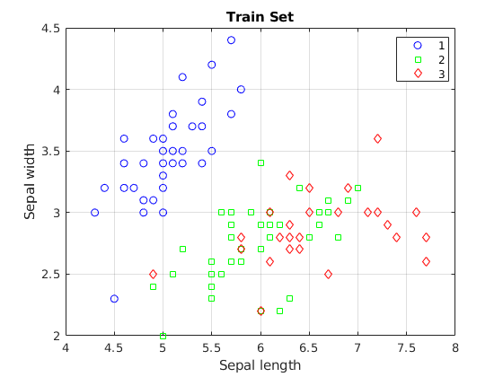

```matlab
shiftIndex = 15;
tmpMeas = meas(1:end-shiftIndex,:);
tmpSpecies = species(1:end-shiftIndex,:);
% split the dataset in train and test set
[xTrain, yTrain, xTest, yTest] = trainTestSplit(tmpMeas, tmpSpecies, validSize, seed);
% plot the train set
plot2DSamples(xTrain, yTrain, featuresLabel, [1,2]);
title('Train Set')
```

# Exercise 3: Impact of the Training set on classification

We define some models using anonymous functions.

```matlab
models{1} = @(x,y) ClassificationDiscriminant.fit(x, y);
models{2} = @(x,y) ClassificationTree.fit(x, y);
models{3} = @(x,y) ClassificationNaiveBayes.fit(x, y);
models{4} = @(x,y) ClassificationKNN.fit(x, y);
modelNames = ["Discriminant Analysis", "Decision Tree", "Naive Bayes", "K-Nearest Neighbors"];
```

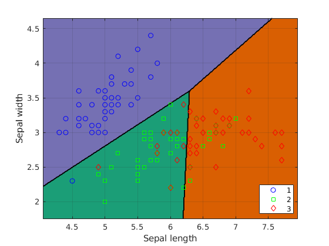

```matlab
% split the dataset in train and test set (use trainTestSplit function)
[xTrain, yTrain, xTest, yTest] = trainTestSplit(meas, species, 0.1, seed);
% train the first model
model = models{1}(xTrain, yTrain);

% plot the classification region
plotClassificationRegion(model, xTrain, yTrain, featuresLabel)
```

# Exercise 4: K-Fold Cross Validation

```matlab
k=50;
trainIter = 1;
[xTrain, yTrain, xTest, yTest] = kFoldSplit(meas, species, k, trainIter, seed);
```

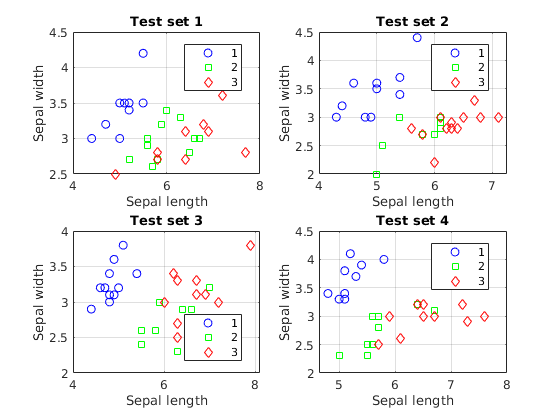

```matlab
% set the number of folds
k=5;
for i=1:4
    subplot(2, 2, i)
    % divide the dataset in k fold and set the i-th fold as test set
    [xTrain, yTrain, xTest, yTest] = kFoldSplit(meas, species, k, i, seed);
    plot2DSamples(xTest, yTest, featuresLabel, [1,2]);
    title(['Test set ' num2str(i)])
end
```

# Take Home Message

- Always look at your data before anything else
  - Examine their dimensions
  - Plot the repartition of features, classes (if provided)
- Define what you want to learn from the data
  - Predicting a certain feature (supervised learning)
  - Clustering your samples (unsupervised learning)
- **Choose a metric** to evaluate the performances of your algorithms